# Exercises STAT340 - PCA

# 1 Track and Field data

The data set `trackfieldrecords` is a `list` with two data tables: The `trackfieldrecords$runMen` and `trackfieldrecords$runWomen` containing national records (a few years ago…) for several track and field events like 100m, 200m and so on up to marathon.

## 1.1 Join data (data wrangling)

Instead of having separate data for men and women, let us join the data into a single table. This means we *join* the data tables by putting them next to each other, but making certain the rows (countries) are aligned correctly. First we load the data and inspect the two data tables

```r
library(tidyverse)
library(BIAS.data)

data(trackfieldrecords)
head(trackfieldrecords$runMen)  # men's records
head(trackfieldrecords$runWomen)  # women's records
```

We notice that the womens records have an `M` before each distance, just like the men. This must be wrong? Let us replace the `M` by a `W`, to indicate which records are for men and which for women:

```r
old.names <- colnames(trackfieldrecords$runWomen)
new.names <- str_replace(old.names, "M", "W")
colnames(trackfieldrecords$runWomen) <- new.names
```

Then we are ready to join the two tables, and we use the column `Nation` as the joining information. This will ensure all records for the same nation are in the same row. This is important, it may be that nations are listed in different order in the two tables. Never ever assume such information is listed in the exact same order in two different data tables!

```r
all.records <- full_join(trackfieldrecords$runMen, trackfieldrecords$runWomen, by = "Nation") %>%
  select(Nation, starts_with("W"), starts_with("M"))  # just a new ordering of the columns
```

## 1.2 Inspect data

Explore the data by making a correlation plot. for example by using `ggcorr()`-function from the `GGally`-package (you need to install it).

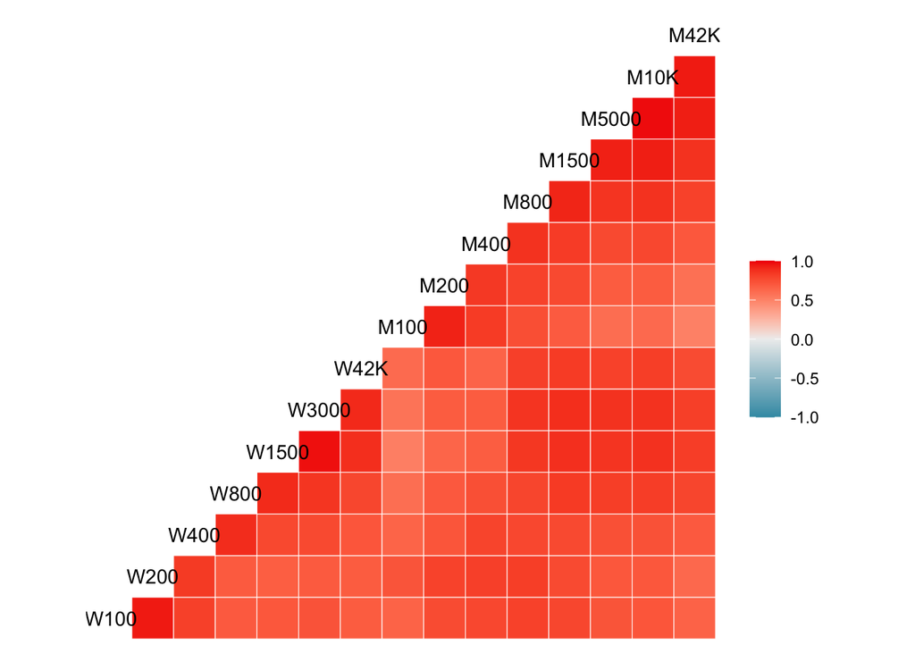

```r
library(GGally)
ggcorr(all.records)
```

What is the big picture we see from this?

**Solution**

All correlations are positive, and also pretty high. These are correlations between the variables. It simply means that if a nation has good/bad running records for one variable, it has similar good/bad for the others as well. This indicates to us that these variables carry to a large degree the same information. We then expect a PCA should show most information is captured with 1 or at least very few components.

## 1.3 PCA

Run a PCA with the `prcomp()`-function (and with `scale = FALSE`) on the data and print out a `summary()` of the resulting object (do not include the first column with names of nations). How many components is needed to explain at least 99% of the variation in the data?

Also, print the loadings for the first two principal components. Try to give an interpretation of them, and explain why so much of the total variability is found in the first component.

**Solution**

```r
pca.obj <- prcomp(all.records[,-1], scale=FALSE)
summary(pca.obj)
```

[output not shown]

```r
pca.obj$rotation[,1:2]
```

```
##                PC1           PC2
## W100  0.0001579187  2.082670e-04
## W200  0.0003880344  3.846436e-04
## W400  0.0009544917  1.409974e-03
## W800  0.0026125664  4.488856e-03
## W1500 0.0092081257  1.079349e-02
## W3000 0.0234509234  2.179258e-02
## W42K  0.9705526811 -2.397032e-01
## M100  0.0001129672  3.430373e-05
## M200  0.0002359479  8.729756e-05
## M400  0.0004967366  1.176565e-03
## M800  0.0016581838  2.678708e-03
## M1500 0.0041712281  8.455720e-03
## M5000 0.0209888188  6.210134e-02
## M10K  0.0482112042  1.399677e-01
## M42K  0.2336654257  9.583324e-01
```

Variation in data is now mainly due to the varying distances. Large values for large distances and small values for short distances. This is an example of data where PC1 picks up the ‘obvious’ and overwhelming cause of why the data varies. From the loadings, see that the loading weight for the 42k’s (Marathon) is totally dominating with a weight of 0.97 (Women) and 0.23 (Men). All other weights are small. PC1 is therefore more or less identical to the Marathon variables. Note that this ‘signal’ may not be very interesting, everyone knows it takes more time to run a Marathon than a 100m, and therefore the variance for these variables are much bigger. We should consider scaling these data, to get rid of this rather obvious, and uninteresting, source of variation.

## 1.4 Standardizing

Re-run the PCA with option `scale. = TRUE` in `prcomp()`, which means the variables are standardized prior to the PCA. How many variables are needed to explain 99% of the variation in this case? How much is explained by the two first components? How would you interpret the loadings of PC1, PC2 and PC3?

**Solution**

```r
pca.obj <- prcomp(all.records[,-1], scale. = TRUE)
summary(pca.obj)
```

```
## Importance of components:
##                           PC1     PC2     PC3     PC4     PC5     PC6     PC7
## Standard deviation     3.4353 1.09500 0.74177 0.65796 0.58786 0.41003 0.34445
## Proportion of Variance 0.7867 0.07994 0.03668 0.02886 0.02304 0.01121 0.00791
## Cumulative Proportion  0.7867 0.86668 0.90336 0.93222 0.95526 0.96647 0.97438
##                           PC8     PC9    PC10    PC11    PC12    PC13    PC14
## Standard deviation     0.2792 0.26614 0.25574 0.23029 0.21737 0.18253 0.14418
## Proportion of Variance 0.0052 0.00472 0.00436 0.00354 0.00315 0.00222 0.00139
## Cumulative Proportion  0.9796 0.98430 0.98866 0.99219 0.99534 0.99756 0.99895
##                           PC15
## Standard deviation     0.12547
## Proportion of Variance 0.00105
## Cumulative Proportion  1.00000
```

```r
pca.obj$rotation[,1:3]
```

```
##             PC1         PC2         PC3
## W100  0.2494938  0.22916891 -0.43003474
## W200  0.2499265  0.31124458 -0.37761294
## W400  0.2545779  0.09804269 -0.45016008
## W800  0.2605318 -0.13846373 -0.19588480
## W1500 0.2637265 -0.29319925 -0.13350152
## W3000 0.2663884 -0.24316904 -0.07692369
## W42K  0.2549046 -0.17213120  0.02140752
## M100  0.2215773  0.47029647  0.41988423
## M200  0.2452074  0.38757612  0.23030488
## M400  0.2564228  0.27814472  0.16950338
## M800  0.2749963  0.04064511  0.10197576
## M1500 0.2778760 -0.09008025  0.13937108
## M5000 0.2690869 -0.21589727  0.18961344
## M10K  0.2704544 -0.21735813  0.21863434
## M42K  0.2524776 -0.30776052  0.18871504
```

We need 11 components to achieve 99% explained variance.

We notice PC1 has almost the same coordinate for all variables, indicating an average over all distances. We may think of this as a general ‘goodness’ in the nation’s records, regardless of distance. The distance-effect is now in PC2 instead. In PC3 we see the effect of gender (men versus women).

## 1.5 Scores and loadings

Make a score-plot and a loading-plot with the first two components using the code below. You may use `geom_text()` instead of `geom_point()` and use `Nation` as the label in `geom_text()`.

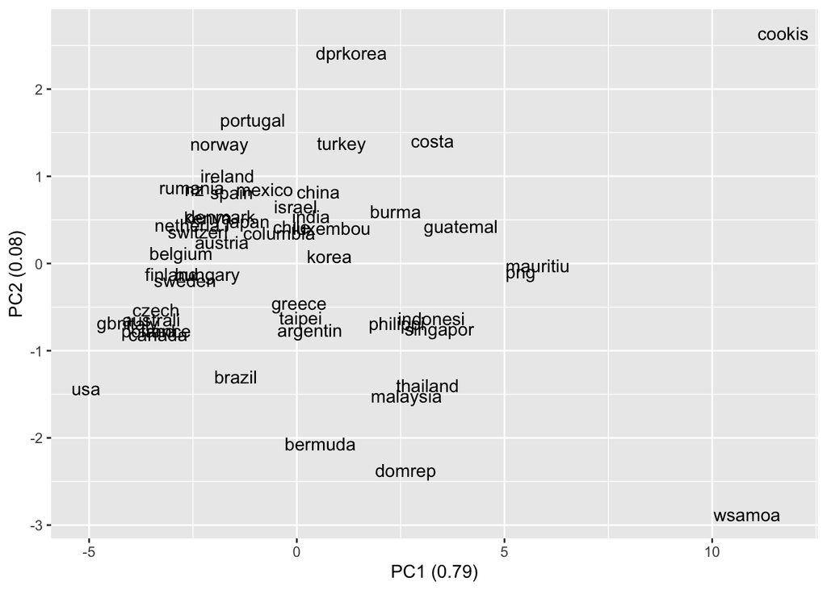

```r
score.tbl <- as.data.frame(pca.obj$x) %>%
  bind_cols(all.records)
relative.evar <- round(pca.obj$sdev^2 / sum(pca.obj$sdev^2), 2)
ggplot(score.tbl) +
  geom_text(aes(x = PC1, y = PC2, label = Nation)) +
  labs(x = str_c("PC1 (", relative.evar[1], ")"),
       y = str_c("PC2 (", relative.evar[2], ")"))
```

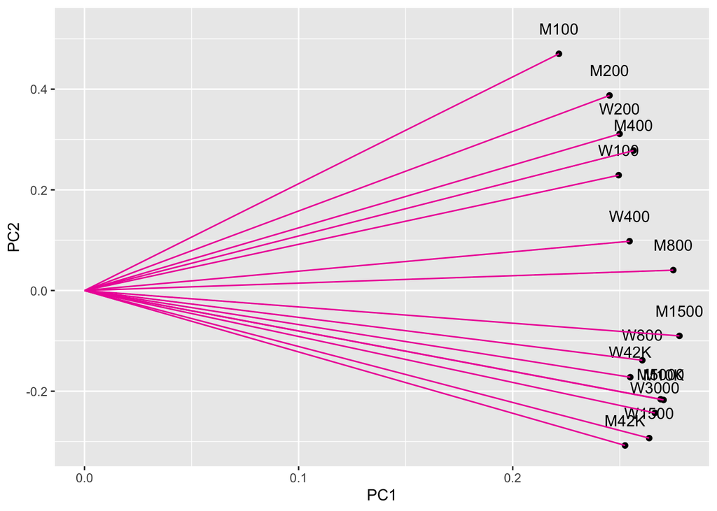

```r
loading.tbl <- as_tibble(pca.obj$rotation, rownames = "Variables")
origin.tbl <- as_tibble(pca.obj$rotation - pca.obj$rotation, rownames = "Variables") %>%
  bind_rows(loading.tbl)
ggplot(loading.tbl, aes(x = PC1, y = PC2)) +
  geom_point() +
  geom_text(aes(label = Variables), nudge_y = 0.05) +
  geom_line(aes(group = Variables), data = origin.tbl, color = "maroon2")
```

Give comments to how the nations distribute relative to the loadings.

Then, edit the code to plot instead PC1 versus PC3. Comment as above.

**Solution**

Consider first the score-plot with PC1-PC2 and where the countries are located here. In such plots we typically look for either clusters/groupings in the data, or for gradients, i.e. the objects (countries) are ‘ordered’ in some direction. For those interested in track-and-fields will notice countries with small (negative) values along PC1 are those who tend to dominate these sports, while on the other end we find countries rarely seen on the Olympic podium. Thus, here PC1 simply reflects the ‘goodness’ of the nations in terms of their records. A larger PC1 loading means a larger (=poorer) record.

Considering the PC1-PC2 loading-plot, i.e. the variables, we see the clear gradient along PC2 reflecting the distances. Nations are distributed along this axis depending if their athletes tend to be good in short or long distances.

# 2 Sediments data

Virtually all environments on this planet may be characterized by their *microbial composition*, i.e. which micro-organisms they inhabit and at which abundances we observe the various taxa. This is done by *sequencing*, and the *read-count* from sequencing is a measure of the abundance for the various taxa.

The data `sediments` contains the read-counts of 4112 prokaryotes (micro-organisms, mainly bacteria) in seafloor sediments collected at 12 selected locations along the Norwegian coast. Each variable is the abundance of a named genus. A large value means a large abundance, but the *sequencing depth* varies between the samples (rows), i.e. if you sum the values in each row they are not identical.

The first column is the type of environment of the sample, here described as either `Natural` or `Polluted`.

## 2.1 PCA

Make a PCA of the numerical data (not `Environment`). How much of the total variation is explained by the first PCs?

**Solution**

```r
library(tidyverse)
library(BIAS.data)
data(sediments)

pca.obj <- prcomp(sediments[,-1], scale. = F)
summary(pca.obj)
```

```
## Importance of components:
##                              PC1       PC2       PC3       PC4       PC5
## Standard deviation     6.273e+05 1.187e+05 6.197e+04 3.951e+04 3.726e+04
## Proportion of Variance 9.481e-01 3.393e-02 9.250e-03 3.760e-03 3.340e-03
## Cumulative Proportion  9.481e-01 9.820e-01 9.912e-01 9.950e-01 9.983e-01
##                              PC6       PC7       PC8       PC9      PC10
## Standard deviation     1.818e+04 1.351e+04 1.060e+04 6478.5516 4.195e+03
## Proportion of Variance 8.000e-04 4.400e-04 2.700e-04    0.0001 4.000e-05
## Cumulative Proportion  9.991e-01 9.996e-01 9.999e-01    1.0000 1.000e+00
##                             PC11      PC12
## Standard deviation     1.886e+03 2.636e-10
## Proportion of Variance 1.000e-05 0.000e+00
## Cumulative Proportion  1.000e+00 1.000e+00
```

Here 98.2% of the variation is described by the first two PC’s, and almost 95% by the first PC alone. This means we essentially only need 1 principal component to describe almost all variation in these data.

## 2.2 Scoreplot

Make a score-plot, and color by the `Environment` using the code below. Imagine you are to explain this plot to someone else, what would you say? What is your interpretation of PC1 here?

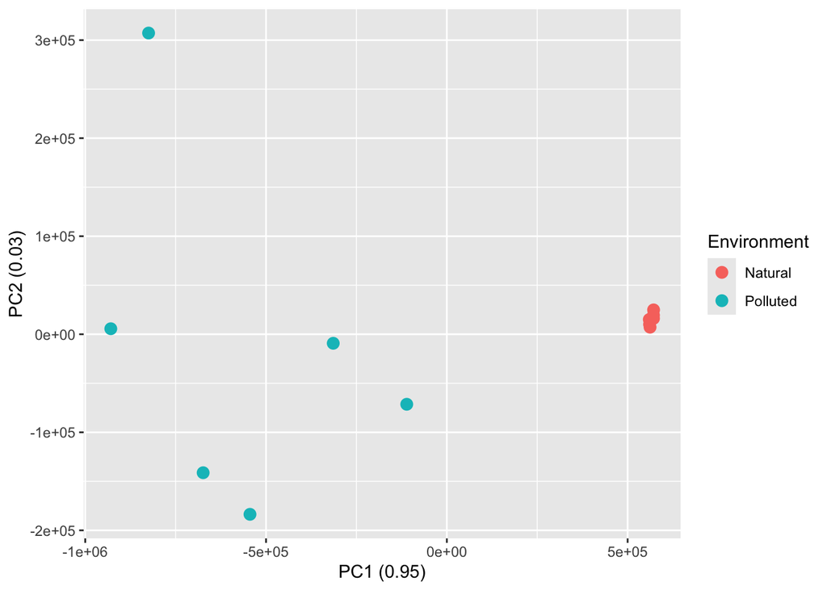

```r
library(tidyverse)
score.tbl <- as.data.frame(pca.obj$x) %>%
  bind_cols(sediments)
relative.evar <- round(pca.obj$sdev^2 / sum(pca.obj$sdev^2), 2)
ggplot(score.tbl) +
  geom_point(aes(x = PC1, y = PC2, color = Environment), size = 3) +
  labs(x = str_c("PC1 (", relative.evar[1], ")"),
       y = str_c("PC2 (", relative.evar[2], ")"))
```

**Solution**

The score plot gives us the original data in the new coordinate system. We take a look at where the points are located and look for clusters/grouping. When colored by environment the score plot tells us that there is a difference between natural and polluted environments.

Here the variation of the PC1 axis explains almost everything (95%), and any variation in the y-axis direction is probably just random noise. A plot like this should be wide but short (low), i.e. a long x-axis and a very short y-axis, to avoid the viewer from starting to ‘interpret’ variation along the y-axis.

## 2.3 Loading-plot

Make a loading-plot using the code below. Again, try to explain what this plot shows.

If we wanted to quickly determine if seafloor sediments are polluted or not, which organisms should we look for in our samples? Is a large abundance of this an indication of a polluted or clean environment?

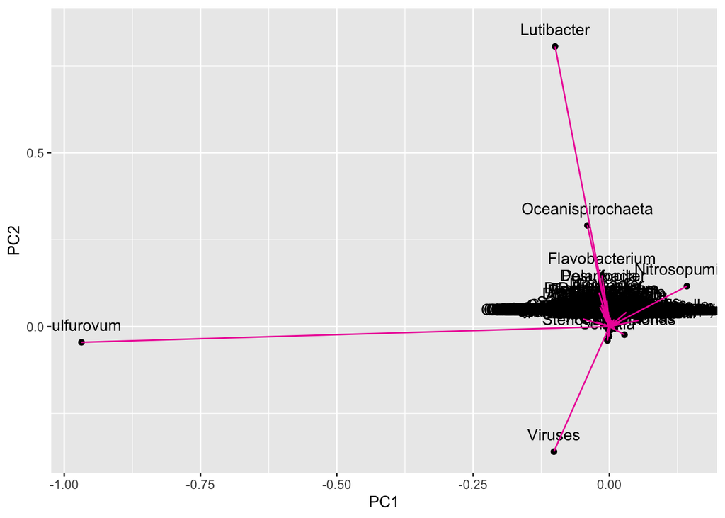

```r
loading.tbl <- as_tibble(pca.obj$rotation, rownames = "Variables")
origin.tbl <- as_tibble(pca.obj$rotation - pca.obj$rotation, rownames = "Variables") %>%
  bind_rows(loading.tbl)
ggplot(loading.tbl, aes(x = PC1, y = PC2)) +
  geom_point() +
  geom_text(aes(label = Variables), nudge_y = 0.05) +
  geom_line(aes(group = Variables), data = origin.tbl, color = "maroon2")
```

**Solution**

The loading-plot shows how strongly each variable influences a PC. The angles between the vectors tell us how variables correlate with one another (described above) if two variables form a small angle, the two variables are correlated. It is hard to tell from our plot as they are very clustered. But we can see Lutibacter and Oceanispirochaeta are positively correlated, while Lutibacter is negatively correlated to Viruses.

The loading-plot can tell us which variables are mostly correlated with PC1 and PC2. We saw from the score-plot that PC1 separate polluted from natural sites (see score plot). In the loading-plot we see that Sulfurovum is the genus that has the (by far!) largest absolute loading along PC1. A high abundance of this is associated with polluted sites, since it has a negative loading along PC1, and polluted sites also had a negative score along PC1. Thus, if we observe a very high abundance of this taxon compared to the rest, we predict it is a polluted environment.

## 2.4 Standardizing

Try to re-run the analyses above, but standardize the data prior to the PCA. What does these results tell us?

**Solution**

```r
data(sediments)

pca.obj <- prcomp(sediments[,-1], scale. = T)
summary(pca.obj)
```

```
## Importance of components:
##                            PC1     PC2      PC3      PC4      PC5     PC6
## Standard deviation     53.1381 21.5204 15.96213 13.95490 11.38407 7.38610
## Proportion of Variance  0.6867  0.1126  0.06196  0.04736  0.03152 0.01327
## Cumulative Proportion   0.6867  0.7993  0.86128  0.90864  0.94015 0.95342
##                            PC7     PC8     PC9    PC10    PC11      PC12
## Standard deviation     6.82804 6.53325 6.27424 5.85203 5.34969 2.186e-14
## Proportion of Variance 0.01134 0.01038 0.00957 0.00833 0.00696 0.000e+00
## Cumulative Proportion  0.96476 0.97514 0.98471 0.99304 1.00000 1.000e+00
```

When scaled, 80% of the variation is described by the first two PC’s, much less than before.

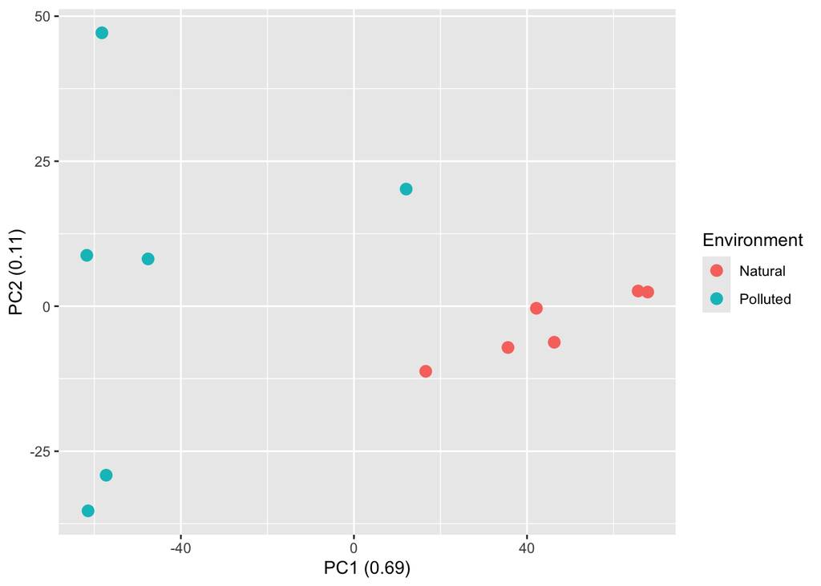

```r
score.tbl <- as.data.frame(pca.obj$x) %>%
  bind_cols(sediments)
relative.evar <- round(pca.obj$sdev^2 / sum(pca.obj$sdev^2), 2)
ggplot(score.tbl) +
  geom_point(aes(x = PC1, y = PC2, color = Environment), size = 3) +
  labs(x = str_c("PC1 (", relative.evar[1], ")"),
       y = str_c("PC2 (", relative.evar[2], ")"))
```

When scaled the major difference. along PC1, is still between polluted and natural sites, but not as clear as before.

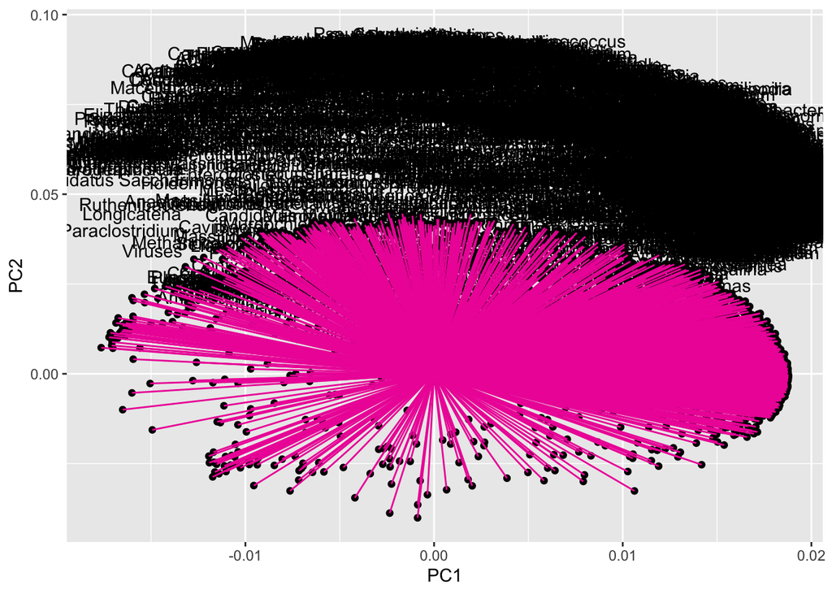

```r
loading.tbl <- as_tibble(pca.obj$rotation, rownames = "Variables")
origin.tbl <- as_tibble(pca.obj$rotation - pca.obj$rotation, rownames = "Variables") %>%
  bind_rows(loading.tbl)
ggplot(loading.tbl, aes(x = PC1, y = PC2)) +
  geom_point() +
  geom_text(aes(label = Variables), nudge_y = 0.05) +
  geom_line(aes(group = Variables), data = origin.tbl, color = "maroon2")
```

Well, a loading plot with this many standardized variables quickly becomes a mess! Since all variables now have standard deviation 1.0, they tend to be on a circle/ellipsoide around the origin. In such cases a loading-plot is of little help to explore our data!

In fact, for data like this it makes no sense to standardize. The point is that all variables are measured on the same scale (read-counts), and the information lies mostly in that some organisms are more or less abundant, i.e. have larger or smaller values. By standardizing we eliminate much of this information! It is almost remarkable that the score-plot still separates polluted from natural environments.